# Cómo hacer e interpretar un gráfico Q-Q

Parte 4 · Regresión lineal simple

# 1 ¿Qué es un gráfico Q-Q?

Un gráfico Q-Q (*quantile-quantile*, cuantil-cuantil) compara los **cuantiles** de una muestra con los cuantiles de una distribución teórica. En regresión lo usamos con los **residuos** para evaluar si siguen una distribución normal.

- **Eje horizontal:** cuantiles teóricos de la normal estándar.
- **Eje vertical:** cuantiles observados de los residuos ordenados.

Si los residuos son normales, los puntos caen cerca de una recta.

# 2 Paso a paso para construirlo a mano

Supongamos $n$ residuos. Para cada uno:

1. Ordenarlos de menor a mayor: $e_{(1)} \le e_{(2)} \le \dots \le e_{(n)}$.
2. Calcular la **posición de probabilidad** de cada uno: $p_i = \dfrac{i - 0.5}{n}$.
3. Obtener el **cuantil teórico** de la normal: $q_i = \Phi^{-1}(p_i)$, donde $\Phi^{-1}$ es la inversa de la distribución normal estándar.
4. Graficar los pares $(q_i,\ e_{(i)})$.

**Código**

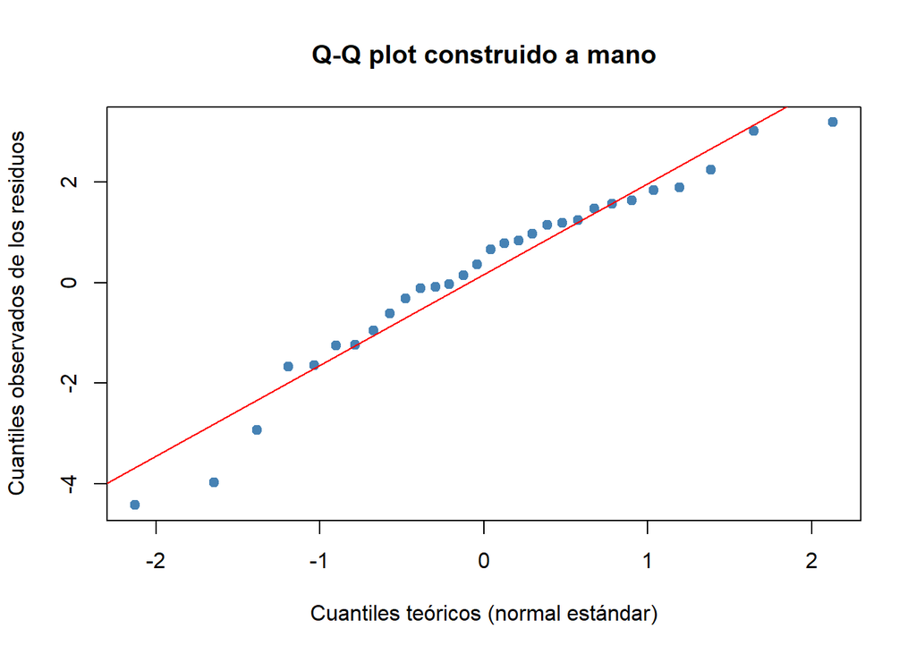

```r
set.seed(1)
e <- rnorm(30, mean = 0, sd = 2)     # residuos de ejemplo

n <- length(e)
e_ord <- sort(e)                      # paso 1: ordenar
p <- (1:n - 0.5) / n                  # paso 2: posiciones de probabilidad
q <- qnorm(p)                         # paso 3: cuantiles teóricos

plot(q, e_ord, pch = 19, col = "steelblue",
     xlab = "Cuantiles teóricos (normal estándar)",
     ylab = "Cuantiles observados de los residuos",
     main = "Q-Q plot construido a mano")
abline(lm(e_ord ~ q), col = "red")   # recta de referencia aproximada
```

# 3 Con R, en una línea

R hace los pasos anteriores automáticamente:

**Código**

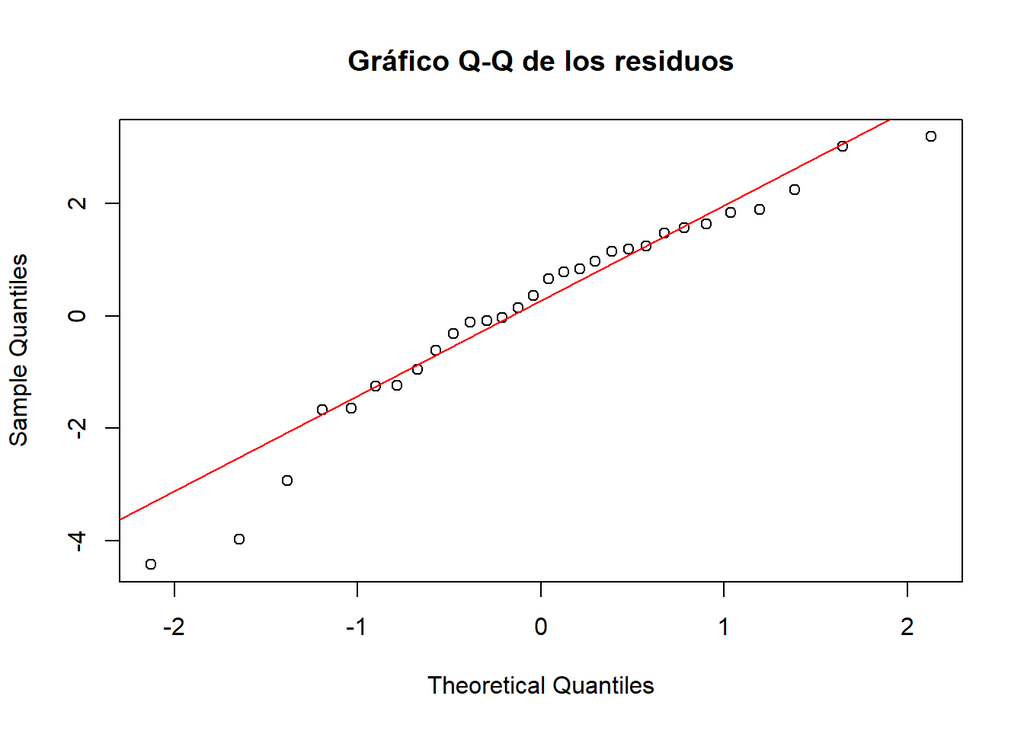

```r
qqnorm(e, main = "Gráfico Q-Q de los residuos")
qqline(e, col = "red")
```

Para un modelo ajustado:

**Código**

```r
modelo <- lm(y ~ x, data = datos)     # reemplazar por tu modelo
qqnorm(residuals(modelo), main = "Q-Q de los residuos")
qqline(residuals(modelo), col = "red")
```

# 4 Cómo interpretarlo

| Patrón observado | Qué indica | Qué hacer |
| --- | --- | --- |
| Puntos sobre la recta | Normalidad razonable | Continuar con la inferencia |
| Colas que se separan de la recta (en ambos extremos) | Colas más pesadas que la normal | Revisar valores extremos; considerar transformar $Y$ |
| Curva en forma de S | Asimetría | Probar transformación logarítmica o raíz cuadrada |
| Un único punto alejado | Posible valor atípico | Verificar el dato y su distancia de Cook |

**Recordar:** con muestras chicas, el gráfico tiene mucha variabilidad aunque los datos sean normales. Conviene combinarlo con la prueba de Shapiro-Wilk, `shapiro.test(residuals(modelo))`.